# MG221 Assignment

```r
source('normality.r')
```

```r
d=read.table("titanic.data")
```

```r
head(d)
summary(d)
```

A data.frame: 6 × 5

| V1 <fct> | V2 <fct> | V3 <fct> | V4 <fct> | V5 <fct> |
| --- | --- | --- | --- | --- |
| Name | PClass | Age | Gender | Survived |
| Allen, Miss Elisabeth Walton | 1st | 29 | female | 1 |
| Allison, Miss Helen Loraine | 1st | 2 | female | 0 |
| Allison, Mr Hudson Joshua Creighton | 1st | 30 | male | 0 |
| Allison, Mrs Hudson JC (Bessie Waldo Daniels) | 1st | 25 | female | 0 |
| Allison, Master Hudson Trevor | 1st | 0.92 | male | 1 |

```
                            V1            V2            V3           V4
 Carlsson, Mr Frans Olof     :   2   1st   :322   22     : 35   female:462
 Connolly, Miss Kate         :   2   2nd   :280   21     : 31   Gender:  1
 Kelly, Mr James             :   2   3rd   :711   30     : 31   male  :851
 Abbing, Mr Anthony          :   1   PClass:  1   18     : 30
 Abbott, Master Eugene Joseph:   1                36     : 29
 Abbott, Mr Rossmore Edward  :   1                (Other):601
 (Other)                     :1305                NA's   :557
        V5
 0       :863
 1       :450
 Survived:  1
```

Q1) Is there a significant difference in Age distribution b/w those who survived and those who did not?

```r
S=subset(d,d$V5==1) # Survivors
NS = subset(d,d$V5==0) # Non-Survivors
```

```r
t1=as.numeric(as.character(S$V3))
t2=as.numeric(as.character(NS$V3))
t1 = na.omit(t1)
t2 = na.omit(t2)
```

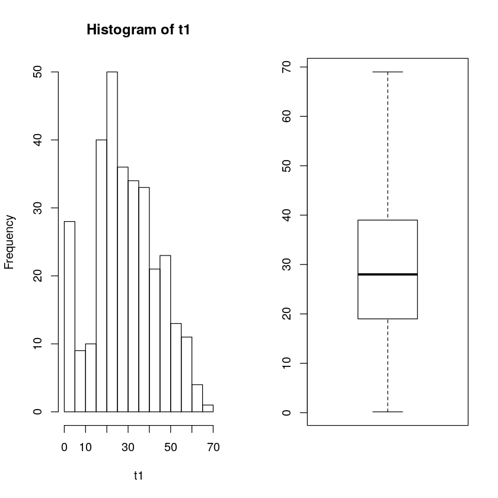

```r
par(mfrow=c(1,2))
hist(t1)
boxplot(t1)
```

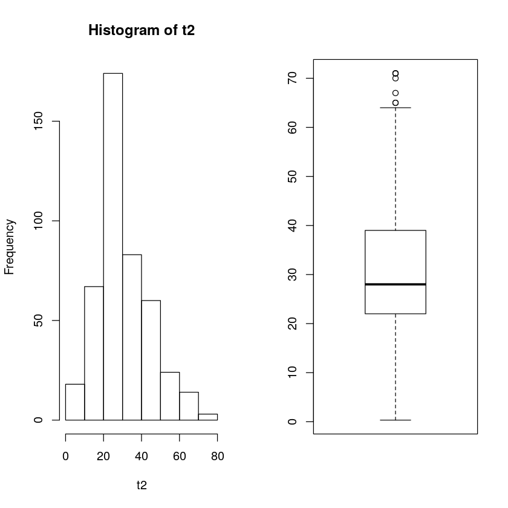

```r
par(mfrow=c(1,2))
hist(t2)
boxplot(t2)
```

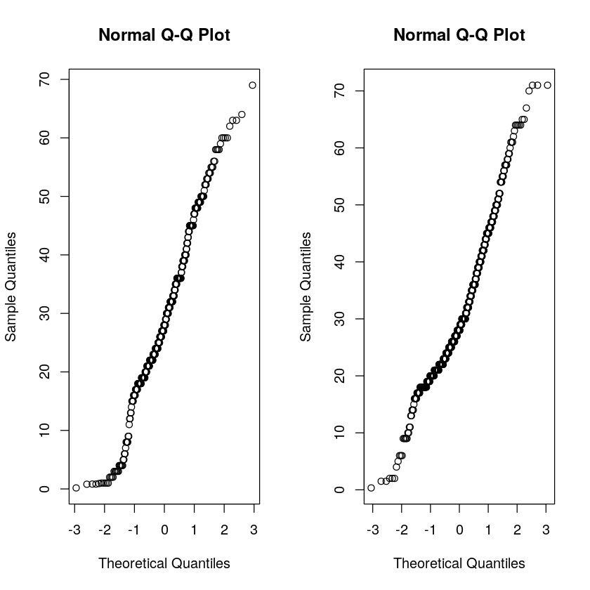

```r
par(mfrow=c(1,2))
qqnorm(t1)
qqnorm(t2)
```

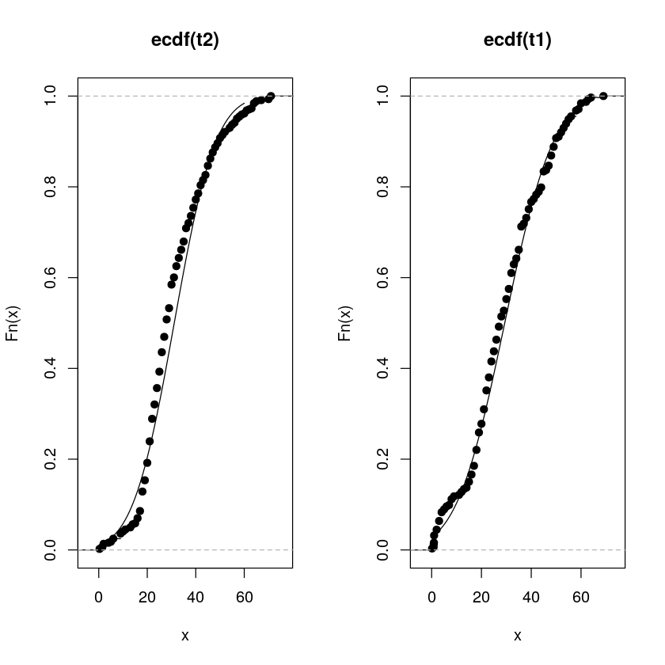

```r
par(mfrow=c(1,2))
plot(ecdf(t2))
lines(seq(0,60,1),pnorm(seq(0,60,1),mean(t2),sd(t2)))
plot(ecdf(t1))
lines(seq(0,60,1),pnorm(seq(0,60,1),mean(t1),sd(t1)))
```

```r
normtest(t1)
normtest(t2)
```

A data.frame: 5 × 2

| Method <fct> | P.value <dbl> |
| --- | --- |
| Shapiro-Wilk normality test | 0.0004996137 |
| Anderson-Darling normality test | 0.0017831268 |
| Cramer-von Mises normality test | 0.0068092810 |
| Lilliefors (Kolmogorov-Smirnov) normality test | 0.0322461921 |
| Shapiro-Francia normality test | 0.0020591830 |

A data.frame: 5 × 2

| Method <fct> | P.value <dbl> |
| --- | --- |
| Shapiro-Wilk normality test | 1.461444e-09 |
| Anderson-Darling normality test | 5.014279e-16 |
| Cramer-von Mises normality test | 7.370000e-10 |
| Lilliefors (Kolmogorov-Smirnov) normality test | 2.646866e-16 |
| Shapiro-Francia normality test | 1.719147e-08 |

Strong Evidence Against Normality So using non-parametric test

```r
wilcox.test(t1,t2)
```

```
	Wilcoxon rank sum test with continuity correction

data:  t1 and t2
W = 65469, p-value = 0.1917
alternative hypothesis: true location shift is not equal to 0
```

Ans : There is no significant difference in the age distribution of the ones who survived and who didn't

Q2) Is there a significant difference in age distribution between those who survived and those who did not after controlling for gender ?

Controlling for the Gender Male

```r
S=subset(d,(d$V5==1) & (d$V4=='male')) # Survivors
NS = subset(d,(d$V5==0)&(d$V4=='male')) # Non-Survivors
t1=as.numeric(as.character(S$V3))
t2=as.numeric(as.character(NS$V3))
t1 = na.omit(t1)
t2 = na.omit(t2)
```

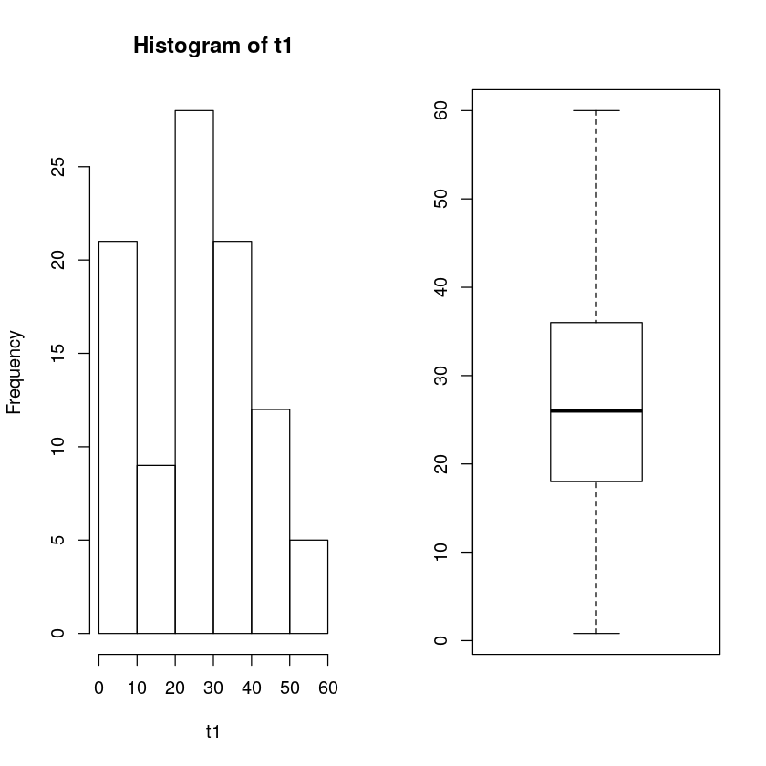

```r
par(mfrow=c(1,2))
hist(t1)
boxplot(t1)
```

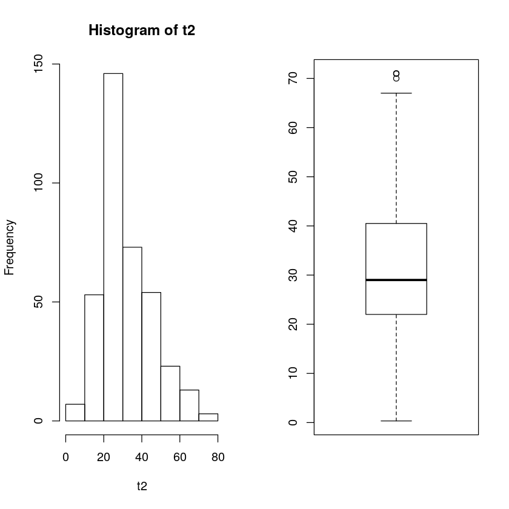

```r
par(mfrow=c(1,2))
hist(t2)
boxplot(t2)
```

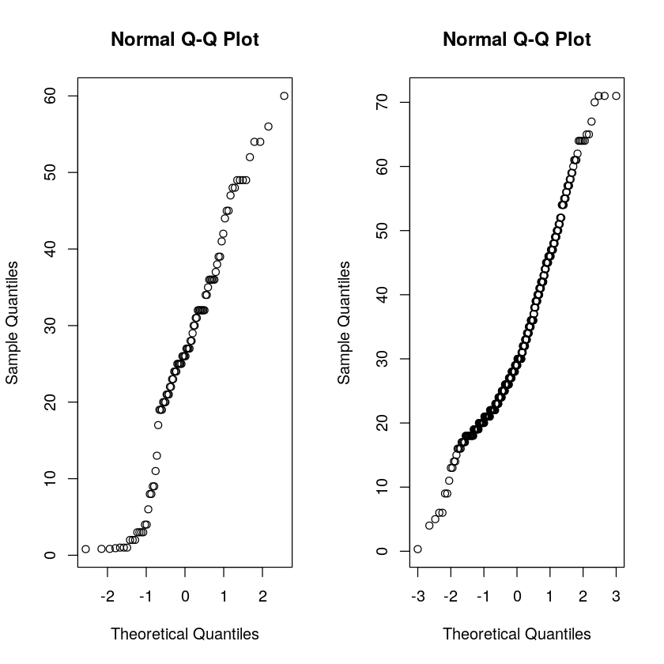

```r
par(mfrow=c(1,2))
qqnorm(t1)
qqnorm(t2)
```

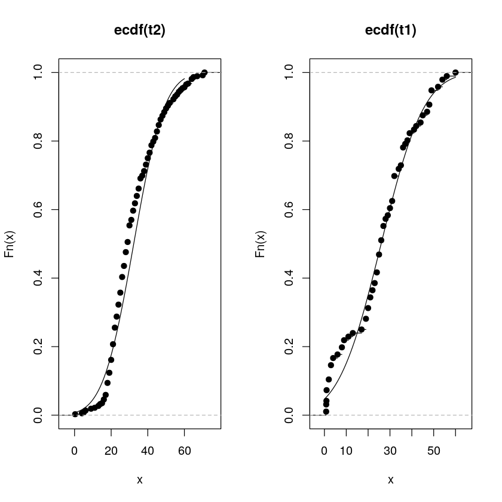

```r
par(mfrow=c(1,2))
plot(ecdf(t2))
lines(seq(0,60,1),pnorm(seq(0,60,1),mean(t2),sd(t2)))
plot(ecdf(t1))
lines(seq(0,60,1),pnorm(seq(0,60,1),mean(t1),sd(t1)))
```

```r
normtest(t1)
normtest(t2)
```

A data.frame: 5 × 2

| Method <fct> | P.value <dbl> |
| --- | --- |
| Shapiro-Wilk normality test | 0.004201276 |
| Anderson-Darling normality test | 0.008390771 |
| Cramer-von Mises normality test | 0.045051620 |
| Lilliefors (Kolmogorov-Smirnov) normality test | 0.059854415 |
| Shapiro-Francia normality test | 0.013508441 |

A data.frame: 5 × 2

| Method <fct> | P.value <dbl> |
| --- | --- |
| Shapiro-Wilk normality test | 6.368376e-10 |
| Anderson-Darling normality test | 2.227363e-16 |
| Cramer-von Mises normality test | 7.370000e-10 |
| Lilliefors (Kolmogorov-Smirnov) normality test | 6.088379e-15 |
| Shapiro-Francia normality test | 8.325134e-09 |

Strong evidence against Normality for Distribution of Age groups for survivors and non survivors after controlling gender as male. Proceeding on to use non-parametric test

```r
wilcox.test(t1,t2)
```

```
	Wilcoxon rank sum test with continuity correction

data:  t1 and t2
W = 14453, p-value = 0.003962
alternative hypothesis: true location shift is not equal to 0
```

There is strong evidence to suggest difference in the age distribution of the ones who survived and who didn't after controlling the gender to male

Controlling for gender female

```r
S=subset(d,(d$V5==1) & (d$V4=='female')) # Survivors
NS = subset(d,(d$V5==0)&(d$V4=='female')) # Non-Survivors
t1=as.numeric(as.character(S$V3))
t2=as.numeric(as.character(NS$V3))
t1 = na.omit(t1)
t2 = na.omit(t2)
```

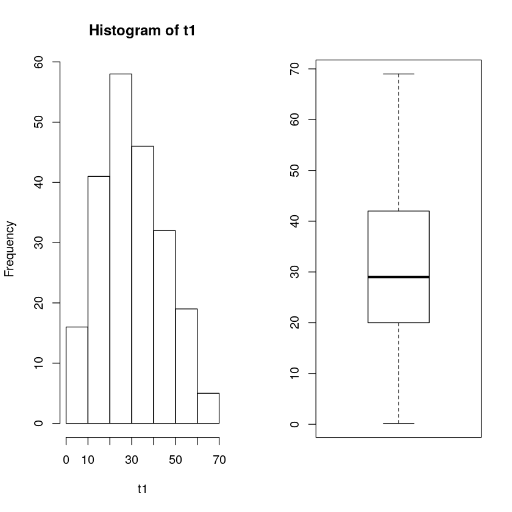

```r
par(mfrow=c(1,2))
hist(t1)
boxplot(t1)
```

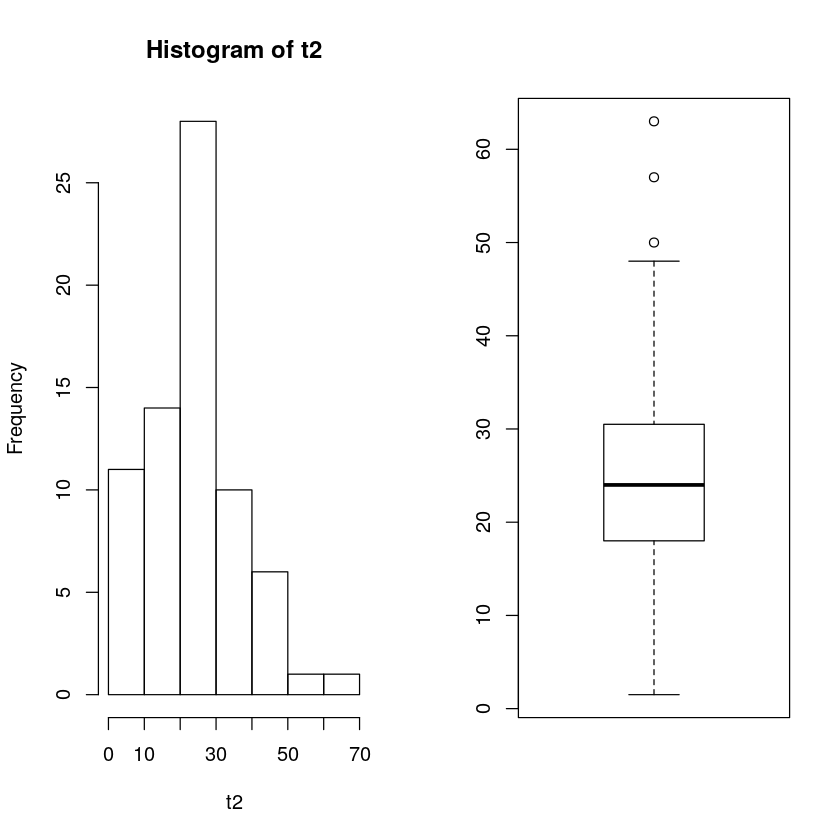

```r
par(mfrow=c(1,2))
hist(t2)
boxplot(t2)
```

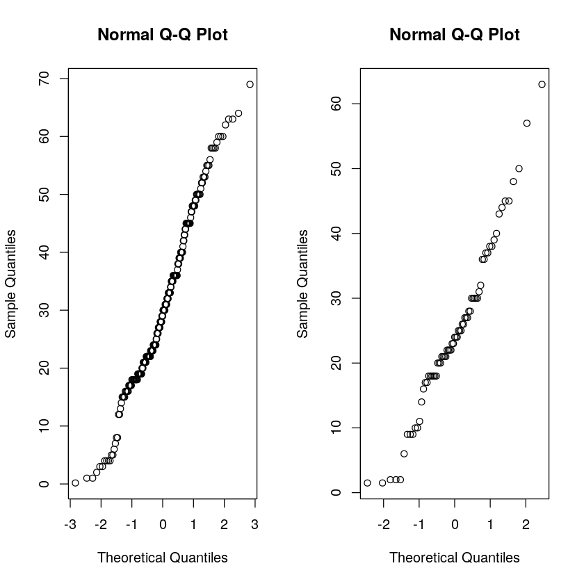

```r
par(mfrow=c(1,2))
qqnorm(t1)
qqnorm(t2)
```

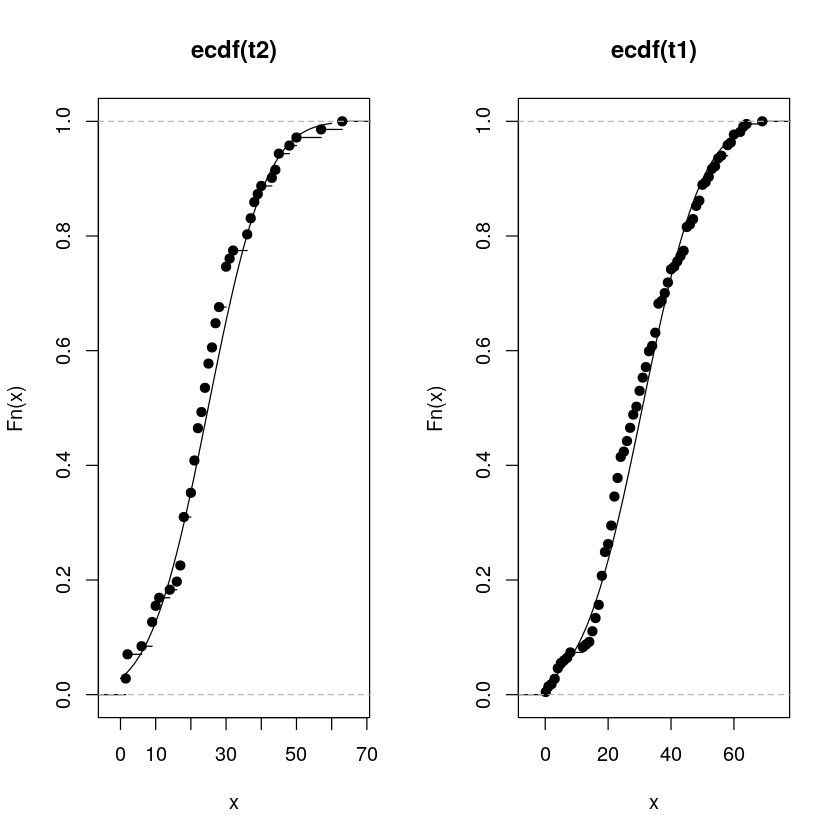

```r
par(mfrow=c(1,2))
plot(ecdf(t2))
lines(seq(0,60,1),pnorm(seq(0,60,1),mean(t2),sd(t2)))
plot(ecdf(t1))
lines(seq(0,60,1),pnorm(seq(0,60,1),mean(t1),sd(t1)))
```

```r
normtest(t1)
normtest(t2)
```

A data.frame: 5 × 2

| Method <fct> | P.value <dbl> |
| --- | --- |
| Shapiro-Wilk normality test | 0.0026901879 |
| Anderson-Darling normality test | 0.0006357403 |
| Cramer-von Mises normality test | 0.0008234442 |
| Lilliefors (Kolmogorov-Smirnov) normality test | 0.0001661670 |
| Shapiro-Francia normality test | 0.0077707718 |

A data.frame: 5 × 2

| Method <fct> | P.value <dbl> |
| --- | --- |
| Shapiro-Wilk normality test | 0.11296551 |
| Anderson-Darling normality test | 0.11530637 |
| Cramer-von Mises normality test | 0.08483381 |
| Lilliefors (Kolmogorov-Smirnov) normality test | 0.12109238 |
| Shapiro-Francia normality test | 0.11744076 |

There is strong evidence against normality in the age distribution for survivors with gender controlled as female and No significant evidence against normality for the age distribution in the non survivors

```r
wilcox.test(t1,t2)
```

```
	Wilcoxon rank sum test with continuity correction

data:  t1 and t2
W = 9408.5, p-value = 0.005119
alternative hypothesis: true location shift is not equal to 0
```

Ans Q2) There is strong evidenve to suggest difference in the age distributions of the ones who survived and the ones who didn't even after controlling for the gender of the individual

Q3) Is there significant difference in the survival probabilities of the 2 gender ?

```r
a = table(as.character(d$V4[-c(1)]),as.character(d$V5[-c(1)]))
a
```

```
           0   1
  female 154 308
  male   709 142
```

```r
chisq.test(a)
```

```
	Pearson's Chi-squared test with Yates' continuity correction

data:  a
X-squared = 329.84, df = 1, p-value < 2.2e-16
```

```r
chisq.test(a,simulate.p.value=T)
```

```
	Pearson's Chi-squared test with simulated p-value (based on 2000
	replicates)

data:  a
X-squared = 332.06, df = NA, p-value = 0.0004998
```

```r
fisher.test(a)
```

```
	Fisher's Exact Test for Count Data

data:  a
p-value < 2.2e-16
alternative hypothesis: true odds ratio is not equal to 1
95 percent confidence interval:
 0.07620521 0.13155709
sample estimates:
odds ratio
 0.1003494
```

```r
fisher.test(a,alt='l')
```

```
	Fisher's Exact Test for Count Data

data:  a
p-value < 2.2e-16
alternative hypothesis: true odds ratio is less than 1
95 percent confidence interval:
 0.0000000 0.1262404
sample estimates:
odds ratio
 0.1003494
```

Ans Q3)There is significant evidence to show there is difference in the survival probabilities of the 2 gender

Q4) Is there significant difference in survival probabilities for the two genders even after taking the effects of passenger class into account?

```r
#Passenger Class 1
p1=subset(d,d$V2=="1st")
#Passenger Class 2
p2=subset(d,d$V2=="2nd")
#Passenger Class 3
p3=subset(d,d$V2=="3rd")

head(p1)
```

A data.frame: 6 × 5

|  | V1 <fct> | V2 <fct> | V3 <fct> | V4 <fct> | V5 <fct> |
| --- | --- | --- | --- | --- | --- |
| 2 | Allen, Miss Elisabeth Walton | 1st | 29 | female | 1 |
| 3 | Allison, Miss Helen Loraine | 1st | 2 | female | 0 |
| 4 | Allison, Mr Hudson Joshua Creighton | 1st | 30 | male | 0 |
| 5 | Allison, Mrs Hudson JC (Bessie Waldo Daniels) | 1st | 25 | female | 0 |
| 6 | Allison, Master Hudson Trevor | 1st | 0.92 | male | 1 |
| 7 | Anderson, Mr Harry | 1st | 47 | male | 1 |

Checking for passenger Class 1st

```r
t1 = table(as.character(p1$V4),as.character(p1$V5))
t1
chisq.test(t1)
fisher.test(t1)
fisher.test(t1,alt='l')
```

```
           0   1
  female   9 134
  male   120  59
```

```
	Pearson's Chi-squared test with Yates' continuity correction

data:  t1
X-squared = 119.64, df = 1, p-value < 2.2e-16
```

```
	Fisher's Exact Test for Count Data

data:  t1
p-value < 2.2e-16
alternative hypothesis: true odds ratio is not equal to 1
95 percent confidence interval:
 0.01397898 0.07139961
sample estimates:
odds ratio
0.03344369
```

```
	Fisher's Exact Test for Count Data

data:  t1
p-value < 2.2e-16
alternative hypothesis: true odds ratio is less than 1
95 percent confidence interval:
 0.00000000 0.06440093
sample estimates:
odds ratio
0.03344369
```

Checking for passenger Class 2nd

```r
t2 = table(as.character(p2$V4),as.character(p2$V5))
t2
chisq.test(t2)
fisher.test(t2)
fisher.test(t2,alt='l')
```

```
           0   1
  female  13  94
  male   148  25
```

```
	Pearson's Chi-squared test with Yates' continuity correction

data:  t2
X-squared = 142.76, df = 1, p-value < 2.2e-16
```

```
	Fisher's Exact Test for Count Data

data:  t2
p-value < 2.2e-16
alternative hypothesis: true odds ratio is not equal to 1
95 percent confidence interval:
 0.01055891 0.05030944
sample estimates:
odds ratio
0.02391888
```

```
	Fisher's Exact Test for Count Data

data:  t2
p-value < 2.2e-16
alternative hypothesis: true odds ratio is less than 1
95 percent confidence interval:
 0.00000000 0.04531073
sample estimates:
odds ratio
0.02391888
```

Checking for passenger Class 3rd

```r
t3 = table(as.character(p3$V4),as.character(p3$V5))
t3
chisq.test(t3)
fisher.test(t3)
fisher.test(t3,alt='l')
```

```
           0   1
  female 132  80
  male   441  58
```

```
	Pearson's Chi-squared test with Yates' continuity correction

data:  t3
X-squared = 63.201, df = 1, p-value = 1.867e-15
```

```
	Fisher's Exact Test for Count Data

data:  t3
p-value = 1.184e-14
alternative hypothesis: true odds ratio is not equal to 1
95 percent confidence interval:
 0.1440935 0.3266507
sample estimates:
odds ratio
 0.2175681
```

```
	Fisher's Exact Test for Count Data

data:  t3
p-value = 9.239e-15
alternative hypothesis: true odds ratio is less than 1
95 percent confidence interval:
 0.0000000 0.3070662
sample estimates:
odds ratio
 0.2175681
```

Strong evidence to say there is significant differnce in the Survival probabilities of the 2 genders even after taking the effect of passenger class int account